# Independence Days

## Tidy Tuesday

This is my eighth contribution to TidyTuesday, which is ‘a weekly podcast and community activity brought to you by the R4DS Online Learning Community’. Their goal is to help R learners learn in real-world contexts.

For more information, visit the [TidyTuesday homepage](https://www.tidytuesday.com/), check out their [GitHub repository](https://github.com/rfordatascience/tidytuesday) and follow the [R4DS Learning Community on Twitter](https://twitter.com/R4DScommunity).

The purpose of these posts is mainly for exercising purposes. Thus, the provided graphs are not necessarily designed to provide the greatest possible insights. However, I always provide the R code for interested people at the page bottom.

## Independence Days

This week’s data comes from [Wikipedia](https://en.wikipedia.org/wiki/List_of_national_independence_days) and was gathered by [Isabella Velasquez](https://github.com/rfordatascience/tidytuesday/issues/352). It contains the dates of countries when they declared independence.

### Day of the week

I plot the independence days depending on the day of the week as a bar plot:

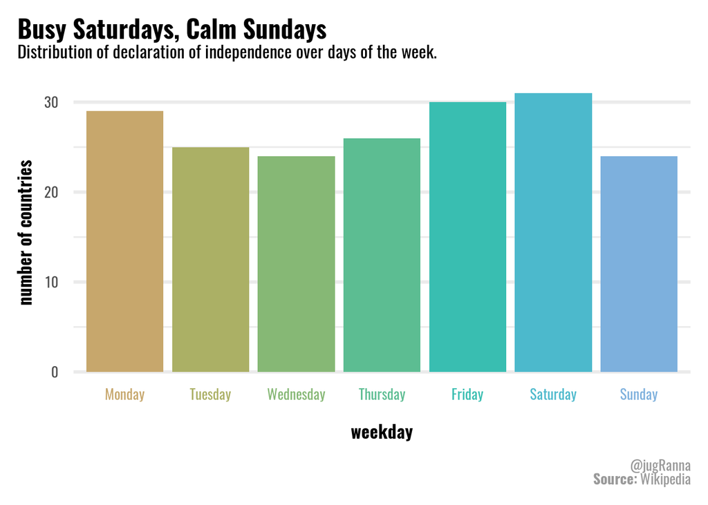

## Distribution over countries

Then, I plot the day of the week over the different countries. This time, I want to try the `mapsf`-package:

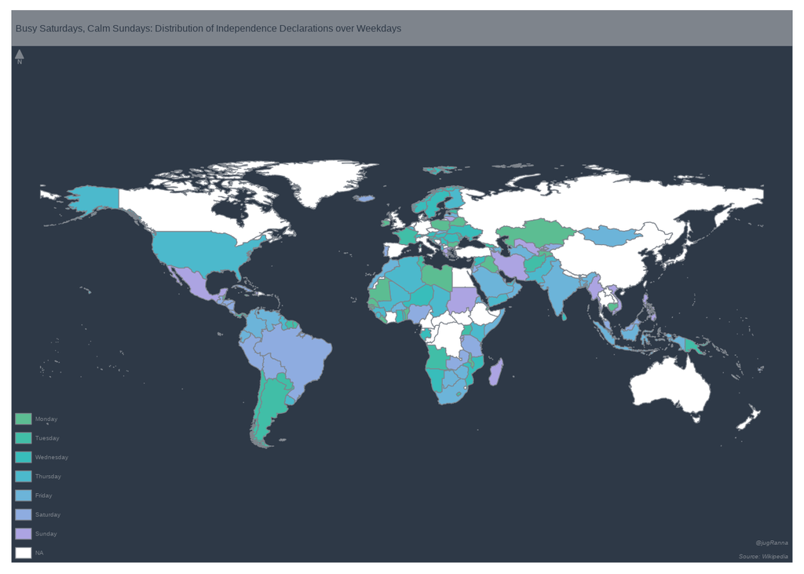

Over the countries, there does not appear to be a particular pattern regarding which weekday differing countries prefer to declare independence. Just a side note: I prefer using the `sf`-package over the `mapsf` package as its usage is more oriented at the usage of `ggplot` / `tidyr`.

Full R code available on [Github](https://github.com/jgranna/tidytuesday/tree/main/2021-07-06).

## References

- `colorspace`**-package**:  
  https://colorspace.r-forge.r-project.org/index.html
- `ggtext`**-package**:  
  https://wilkelab.org/ggtext/
- `mapsf`**-package**:  
  https://riatelab.github.io/mapsf/index.html
- `showtext`**-package**:  
  https://github.com/yixuan/showtext
- `tidyverse`**-package**:  
  https://www.tidyverse.org/